# TIME SERIES FORECASTING - ROSE WINE DATASET

### 5. Check for the stationarity of the data on which the model is being built on using appropriate statistical tests and also mention the hypothesis for the statistical test. If the data is found to be non-stationary, take appropriate steps to make it stationary. Check the new data for stationarity and comment. Note: Stationarity should be checked at alpha = 0.05.

#### Dickey Fuller Test:

Taking Null Hypothesis $H_0$- Series is not Stationary

Taking Alternative Hypothesis $H_1$- Series is Stationary

```python
#importing adfuller

from statsmodels.tsa.stattools import adfuller
```

```python
#creating a function to test the stationarity of the time series


def Stationarity_test(timeseries):

    #rolling mean
    rolmean = timeseries.rolling(window=7).mean()
    #rolling standard deviation
    rolstd = timeseries.rolling(window=7).std()

    #Plotting

    original = plt.plot(timeseries, color='pink',label='Original')
    mean = plt.plot(rolmean, color='black', label='Rolling mean')
    std = plt.plot(rolstd, color='green', label = 'Rolling std')
    plt.legend(loc='best')
    plt.title('Rolling Mean & Standard Deviation')
    plt.show(block=False)
```

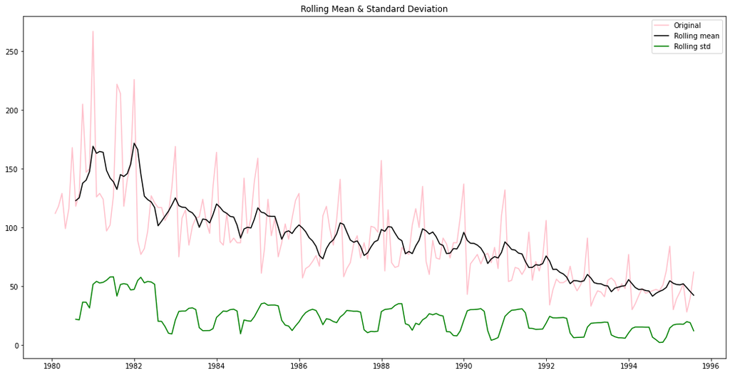

```python
#calling the function

Stationarity_test(rose_data['Rose'])
```

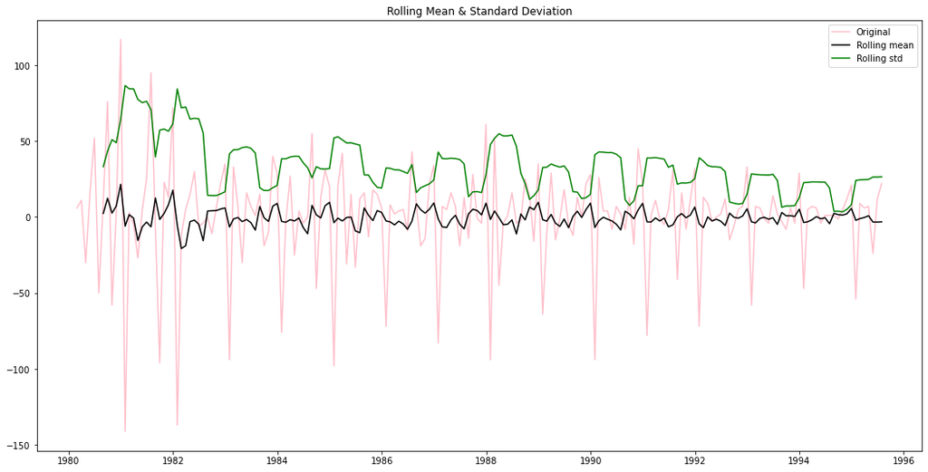

```python
Stationarity_test(rose_data['Rose'].diff().dropna())
```

### 6. Build an automated version of the ARIMA/SARIMA model in which the parameters are selected using the lowest Akaike Information Criteria (AIC) on the training data and evaluate this model on the test data using RMSE.

```python
#we will take the combination of different parameters of p and q in the range of 0 and 2

#we have kept the value of d as 1 as we need to take a difference of the series to make it stationary.

#importing itertools

import itertools
p = q = range(0, 3)
d= range(1,2)
pdq = list(itertools.product(p, d, q))
print('Combination of parameters for the model:')
for i in range(1,len(pdq)):
    print('Model: {}'.format(pdq[i]))
```

```
Combination of parameters for the model:
Model: (0, 1, 1)
Model: (0, 1, 2)
Model: (1, 1, 0)
Model: (1, 1, 1)
Model: (1, 1, 2)
Model: (2, 1, 0)
Model: (2, 1, 1)
Model: (2, 1, 2)
```

```python
# Creating an empty Dataframe with column names only
ARIMA_AIC = pd.DataFrame(columns=['param', 'AIC'])
ARIMA_AIC
```

|  | param | AIC |
| --- | --- | --- |

```python
#importing ARIMA

from statsmodels.tsa.arima_model import ARIMA

for param in pdq:
    ARIMA_model = ARIMA(train['Rose'].values,order=param).fit()
    print('ARIMA{} - AIC:{}'.format(param,ARIMA_model.aic))
    ARIMA_AIC = ARIMA_AIC.append({'param':param, 'AIC': ARIMA_model.aic}, ignore_index=True)
```

```
ARIMA(0, 1, 0) - AIC:1335.1526583086775
ARIMA(0, 1, 1) - AIC:1280.726183046448
ARIMA(0, 1, 2) - AIC:1276.8353734911866
ARIMA(1, 1, 0) - AIC:1319.3483105802602
ARIMA(1, 1, 1) - AIC:1277.775753553521
ARIMA(1, 1, 2) - AIC:1277.3592281129256
ARIMA(2, 1, 0) - AIC:1300.6092611744193
ARIMA(2, 1, 1) - AIC:1279.0456894093354
ARIMA(2, 1, 2) - AIC:1279.2986939365205
```

The lowest AIC value comes out to 1276.83 at ARIMA(0,1,2)

```python
#Now, let's create auto ARIMA by using these parameters

auto_ARIMA = ARIMA(train['Rose'], order=(0,1,2))
results_auto_ARIMA = auto_ARIMA.fit()
print(results_auto_ARIMA.summary())
```

```
                             ARIMA Model Results
==============================================================================
Dep. Variable:                 D.Rose   No. Observations:                  131
Model:                 ARIMA(0, 1, 2)   Log Likelihood                -634.418
Method:                       css-mle   S.D. of innovations             30.167
Date:                Mon, 11 Oct 2021   AIC                           1276.835
Time:                        23:16:13   BIC                           1288.336
Sample:                    02-29-1980   HQIC                          1281.509
                         - 12-31-1990
================================================================================
                   coef    std err          z      P>|z|      [0.025      0.975]
--------------------------------------------------------------------------------
const           -0.4886      0.085     -5.742      0.000      -0.655      -0.322
ma.L1.D.Rose    -0.7601      0.101     -7.499      0.000      -0.959      -0.561
ma.L2.D.Rose    -0.2398      0.095     -2.518      0.012      -0.427      -0.053
                                    Roots
=============================================================================
                  Real          Imaginary           Modulus         Frequency
-----------------------------------------------------------------------------
MA.1            1.0001           +0.0000j            1.0001            0.0000
MA.2           -4.1695           +0.0000j            4.1695            0.5000
-----------------------------------------------------------------------------
```

```python
#prediction on test set

predicted_auto_ARIMA = results_auto_ARIMA.forecast(steps=len(test))
```

```python
#importing mean_squared_error

from sklearn.metrics import  mean_squared_error
```

```python
#Calculating RMSE on test data

RMSE_1 = mean_squared_error(test['Rose'],predicted_auto_ARIMA[0],squared=False)
```

```python
print(RMSE_1)
```

```
15.60419552386519
```

#### Automated SARIMA

```python
import itertools
p = q = range(0, 3)
d= range(1,2)
D = range(0,1)
pdq = list(itertools.product(p, d, q))
model_pdq = [(x[0], x[1], x[2], 12) for x in list(itertools.product(p, D, q))]
print('Combinations of parameter for the SARIMA model:')
for i in range(1,len(pdq)):
    print('Model: {}{}'.format(pdq[i], model_pdq[i]))
```

```
Combinations of parameter for the SARIMA model:
Model: (0, 1, 1)(0, 0, 1, 12)
Model: (0, 1, 2)(0, 0, 2, 12)
Model: (1, 1, 0)(1, 0, 0, 12)
Model: (1, 1, 1)(1, 0, 1, 12)
Model: (1, 1, 2)(1, 0, 2, 12)
Model: (2, 1, 0)(2, 0, 0, 12)
Model: (2, 1, 1)(2, 0, 1, 12)
Model: (2, 1, 2)(2, 0, 2, 12)
```

```python
SARIMA_AIC = pd.DataFrame(columns=['param','seasonal', 'AIC'])
SARIMA_AIC
```

|  | param | seasonal | AIC |
| --- | --- | --- | --- |

```python
import statsmodels.api as sm

for param in pdq:
    for param_seasonal in model_pdq:
        SARIMA_model = sm.tsa.statespace.SARIMAX(train['Rose'].values,
                                            order=param,
                                            seasonal_order=param_seasonal,
                                            enforce_stationarity=False,
                                            enforce_invertibility=False)

        results_SARIMA = SARIMA_model.fit(maxiter=1000)
        print('SARIMA{}x{} - AIC:{}'.format(param, param_seasonal, results_SARIMA.aic))
        SARIMA_AIC = SARIMA_AIC.append({'param':param,'seasonal':param_seasonal ,'AIC': results_SARIMA.aic}, ignore_index=True)
```

```
SARIMA(0, 1, 0)x(0, 0, 0, 12) - AIC:1323.9657875279158
SARIMA(0, 1, 0)x(0, 0, 1, 12) - AIC:1145.4230827207175
SARIMA(0, 1, 0)x(0, 0, 2, 12) - AIC:976.4375296380895
SARIMA(0, 1, 0)x(1, 0, 0, 12) - AIC:1139.921738995602
SARIMA(0, 1, 0)x(1, 0, 1, 12) - AIC:1116.0207869386002
SARIMA(0, 1, 0)x(1, 0, 2, 12) - AIC:969.6913635750373
SARIMA(0, 1, 0)x(2, 0, 0, 12) - AIC:960.8812220353041
SARIMA(0, 1, 0)x(2, 0, 1, 12) - AIC:962.8794540697546
SARIMA(0, 1, 0)x(2, 0, 2, 12) - AIC:955.5735408945867
SARIMA(0, 1, 1)x(0, 0, 0, 12) - AIC:1263.5369097383964
SARIMA(0, 1, 1)x(0, 0, 1, 12) - AIC:1098.5554825918339
SARIMA(0, 1, 1)x(0, 0, 2, 12) - AIC:923.6314049383807
SARIMA(0, 1, 1)x(1, 0, 0, 12) - AIC:1095.793632491795
SARIMA(0, 1, 1)x(1, 0, 1, 12) - AIC:1054.743433094548
SARIMA(0, 1, 1)x(1, 0, 2, 12) - AIC:918.8573483311407
SARIMA(0, 1, 1)x(2, 0, 0, 12) - AIC:914.5982866536075
SARIMA(0, 1, 1)x(2, 0, 1, 12) - AIC:915.3332430461666
SARIMA(0, 1, 1)x(2, 0, 2, 12) - AIC:901.1988257864924
SARIMA(0, 1, 2)x(0, 0, 0, 12) - AIC:1251.667543054104
SARIMA(0, 1, 2)x(0, 0, 1, 12) - AIC:1083.4866975264913
SARIMA(0, 1, 2)x(0, 0, 2, 12) - AIC:913.49384866177
SARIMA(0, 1, 2)x(1, 0, 0, 12) - AIC:1088.8332843413673
SARIMA(0, 1, 2)x(1, 0, 1, 12) - AIC:1045.540093355627
SARIMA(0, 1, 2)x(1, 0, 2, 12) - AIC:904.8310913510973
SARIMA(0, 1, 2)x(2, 0, 0, 12) - AIC:913.0105912257978
SARIMA(0, 1, 2)x(2, 0, 1, 12) - AIC:914.1707545034652
SARIMA(0, 1, 2)x(2, 0, 2, 12) - AIC:887.9375085679284
SARIMA(1, 1, 0)x(0, 0, 0, 12) - AIC:1308.161871082466
SARIMA(1, 1, 0)x(0, 0, 1, 12) - AIC:1135.2955447585719
SARIMA(1, 1, 0)x(0, 0, 2, 12) - AIC:963.9405391257686
SARIMA(1, 1, 0)x(1, 0, 0, 12) - AIC:1124.886078680458
SARIMA(1, 1, 0)x(1, 0, 1, 12) - AIC:1105.4080055024756
SARIMA(1, 1, 0)x(1, 0, 2, 12) - AIC:958.5001972948405
SARIMA(1, 1, 0)x(2, 0, 0, 12) - AIC:939.0984778664119
SARIMA(1, 1, 0)x(2, 0, 1, 12) - AIC:940.9087133661067
SARIMA(1, 1, 0)x(2, 0, 2, 12) - AIC:942.2973103071082
SARIMA(1, 1, 1)x(0, 0, 0, 12) - AIC:1262.1840064255505
SARIMA(1, 1, 1)x(0, 0, 1, 12) - AIC:1094.317270864085
SARIMA(1, 1, 1)x(0, 0, 2, 12) - AIC:923.0862224063868
SARIMA(1, 1, 1)x(1, 0, 0, 12) - AIC:1083.3937965032806
```

[output cut: 26 more lines]

```
SARIMA(2, 1, 1)x(1, 0, 0, 12) - AIC:1071.4249601101342
SARIMA(2, 1, 1)x(1, 0, 1, 12) - AIC:1052.9244471204804
SARIMA(2, 1, 1)x(1, 0, 2, 12) - AIC:916.242491282262
SARIMA(2, 1, 1)x(2, 0, 0, 12) - AIC:896.5181608119215
SARIMA(2, 1, 1)x(2, 0, 1, 12) - AIC:897.639956536955
SARIMA(2, 1, 1)x(2, 0, 2, 12) - AIC:899.4835866288954
SARIMA(2, 1, 2)x(0, 0, 0, 12) - AIC:1253.9102116146685
SARIMA(2, 1, 2)x(0, 0, 1, 12) - AIC:1085.964355259821
SARIMA(2, 1, 2)x(0, 0, 2, 12) - AIC:916.3258311103143
SARIMA(2, 1, 2)x(1, 0, 0, 12) - AIC:1073.2912713704332
SARIMA(2, 1, 2)x(1, 0, 1, 12) - AIC:1044.1909354771824
SARIMA(2, 1, 2)x(1, 0, 2, 12) - AIC:907.666148879695
SARIMA(2, 1, 2)x(2, 0, 0, 12) - AIC:897.3464441348852
SARIMA(2, 1, 2)x(2, 0, 1, 12) - AIC:898.3781889114674
SARIMA(2, 1, 2)x(2, 0, 2, 12) - AIC:890.6687980804124
```

```python
#let's check top 5 lowest AIC values

SARIMA_AIC.sort_values(by=['AIC']).head()
```

|  | param | seasonal | AIC |
| --- | --- | --- | --- |
| 26 | (0, 1, 2) | (2, 0, 2, 12) | 887.937509 |
| 53 | (1, 1, 2) | (2, 0, 2, 12) | 889.902650 |
| 80 | (2, 1, 2) | (2, 0, 2, 12) | 890.668798 |
| 69 | (2, 1, 1) | (2, 0, 0, 12) | 896.518161 |
| 78 | (2, 1, 2) | (2, 0, 0, 12) | 897.346444 |

```python
import statsmodels.api as sm

auto_SARIMA_12 = sm.tsa.statespace.SARIMAX(train['Rose'].values,
                                order=(0, 1, 2),
                                seasonal_order=(2, 0, 2, 12),
                                enforce_stationarity=False,
                                enforce_invertibility=False)
results_auto_SARIMA_12 = auto_SARIMA_12.fit(maxiter=1000)
print(results_auto_SARIMA_12.summary())
```

```
                                     SARIMAX Results
==========================================================================================
Dep. Variable:                                  y   No. Observations:                  132
Model:             SARIMAX(0, 1, 2)x(2, 0, 2, 12)   Log Likelihood                -436.969
Date:                            Mon, 11 Oct 2021   AIC                            887.938
Time:                                    23:16:54   BIC                            906.448
Sample:                                         0   HQIC                           895.437
                                            - 132
Covariance Type:                              opg
==============================================================================
                 coef    std err          z      P>|z|      [0.025      0.975]
------------------------------------------------------------------------------
ma.L1         -0.8427    189.705     -0.004      0.996    -372.658     370.972
ma.L2         -0.1573     29.804     -0.005      0.996     -58.571      58.257
ar.S.L12       0.3467      0.079      4.375      0.000       0.191       0.502
ar.S.L24       0.3023      0.076      3.996      0.000       0.154       0.451
ma.S.L12       0.0767      0.133      0.577      0.564      -0.184       0.337
ma.S.L24      -0.0726      0.146     -0.498      0.618      -0.358       0.213
sigma2       251.3136   4.77e+04      0.005      0.996   -9.32e+04    9.37e+04
===================================================================================
Ljung-Box (L1) (Q):                   0.10   Jarque-Bera (JB):                 2.33
Prob(Q):                              0.75   Prob(JB):                         0.31
Heteroskedasticity (H):               0.88   Skew:                             0.37
Prob(H) (two-sided):                  0.70   Kurtosis:                         3.03
===================================================================================

Warnings:
[1] Covariance matrix calculated using the outer product of gradients (complex-step).
```

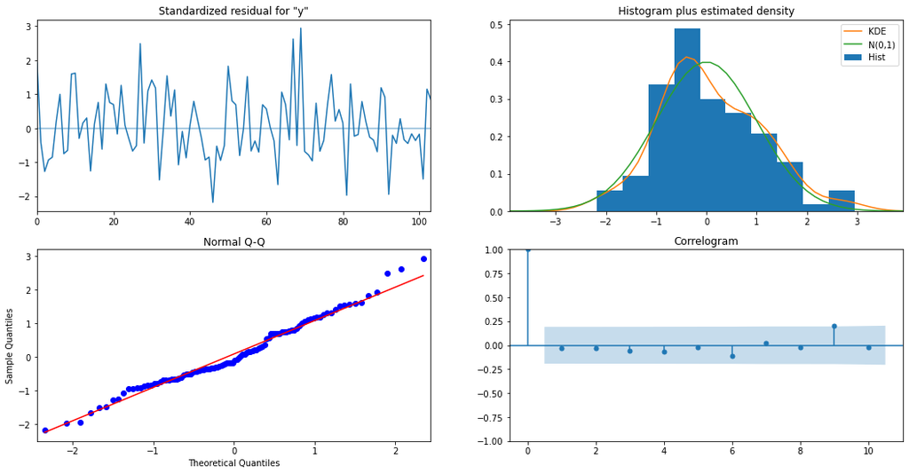

```python
#Plotting

results_auto_SARIMA_12.plot_diagnostics()
plt.show()
```

```python
#prediction on test set

predicted_auto_SARIMA_12 = results_auto_SARIMA_12.get_forecast(steps=len(test))
predicted_auto_SARIMA_12.summary_frame(alpha=0.05).head() #for alpha = 0.05
```

| y | mean | mean_se | mean_ci_lower | mean_ci_upper |
| --- | --- | --- | --- | --- |
| 0 | 62.867263 | 15.928500 | 31.647976 | 94.086550 |
| 1 | 70.541190 | 16.147658 | 38.892361 | 102.190019 |
| 2 | 77.356410 | 16.147656 | 45.707586 | 109.005235 |
| 3 | 76.208814 | 16.147656 | 44.559989 | 107.857638 |
| 4 | 72.747398 | 16.147656 | 41.098573 | 104.396222 |

```python
#Calculating RMSE on test data

rmse_2 = mean_squared_error(test['Rose'],predicted_auto_SARIMA_12.predicted_mean,squared=False)

print(rmse_2)
```

```
26.88062501761389
```

### 7. Build ARIMA/SARIMA models based on the cut-off points of ACF and PACF on the training data and evaluate this model on the test data using RMSE.

```python
#let's plot the ARIMA/SARIMA models with cut off points of ACF and PACF on training data

#import plot_acf and plot_pacf

from statsmodels.graphics.tsaplots import plot_acf, plot_pacf
```

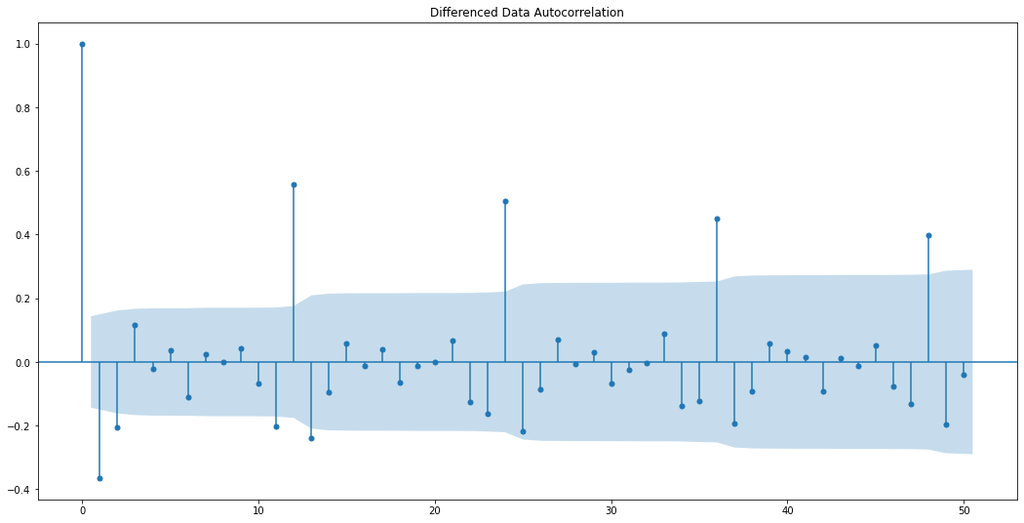

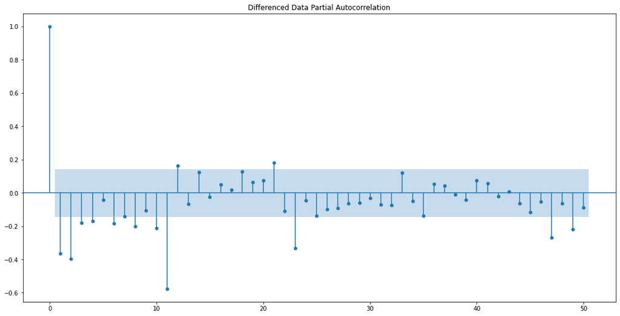

```python
plot_acf(rose_data['Rose'].diff().dropna(),lags=50,title='Differenced Data Autocorrelation')
plot_pacf(rose_data['Rose'].diff().dropna(),lags=50,title='Differenced Data Partial Autocorrelation')
plt.show()
```

```python
#PACF cut off is at lag 4 and
#and ACF plot cuts-off is at lag 2.

#let's look at the summary points on this basis:

manual_ARIMA = ARIMA(train['Rose'].astype('float64'), order=(4,1,2),freq='M')
results_manual_ARIMA = manual_ARIMA.fit()
print(results_manual_ARIMA.summary())
```

```
                             ARIMA Model Results
==============================================================================
Dep. Variable:                 D.Rose   No. Observations:                  131
Model:                 ARIMA(4, 1, 2)   Log Likelihood                -633.876
Method:                       css-mle   S.D. of innovations             29.793
Date:                Mon, 11 Oct 2021   AIC                           1283.753
Time:                        23:16:56   BIC                           1306.754
Sample:                    02-29-1980   HQIC                          1293.099
                         - 12-31-1990
================================================================================
                   coef    std err          z      P>|z|      [0.025      0.975]
--------------------------------------------------------------------------------
const           -0.1905      0.576     -0.331      0.741      -1.319       0.938
ar.L1.D.Rose     1.1685      0.087     13.391      0.000       0.997       1.340
ar.L2.D.Rose    -0.3562      0.132     -2.692      0.007      -0.616      -0.097
ar.L3.D.Rose     0.1855      0.132      1.402      0.161      -0.074       0.445
ar.L4.D.Rose    -0.2227      0.091     -2.443      0.015      -0.401      -0.044
ma.L1.D.Rose    -1.9506        nan        nan        nan         nan         nan
ma.L2.D.Rose     1.0000        nan        nan        nan         nan         nan
                                    Roots
=============================================================================
                  Real          Imaginary           Modulus         Frequency
-----------------------------------------------------------------------------
AR.1            1.1027           -0.4115j            1.1770           -0.0569
AR.2            1.1027           +0.4115j            1.1770            0.0569
AR.3           -0.6863           -1.6644j            1.8003           -0.3122
AR.4           -0.6863           +1.6644j            1.8003            0.3122
MA.1            0.9753           -0.2209j            1.0000           -0.0355
MA.2            0.9753           +0.2209j            1.0000            0.0355
-----------------------------------------------------------------------------
```

```python
predicted_manual_ARIMA = results_manual_ARIMA.forecast(steps=len(test))

#RMSE

rmse_3 = mean_squared_error(test['Rose'],predicted_manual_ARIMA[0],squared=False)
print(rmse_3)
```

```
33.90482729155276
```

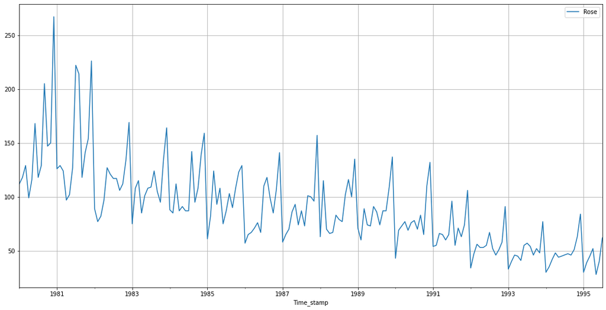

```python
rose_data.plot()
plt.grid()
plt.show()
```

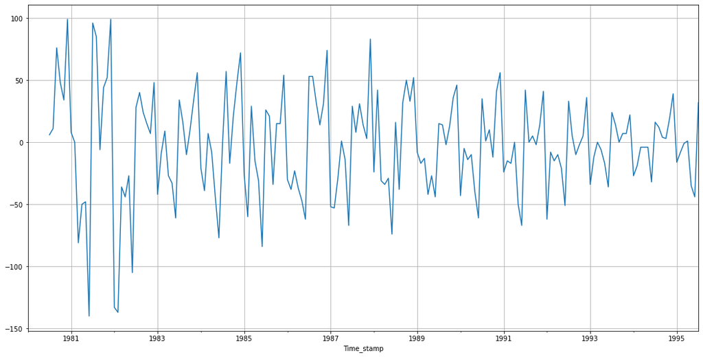

```python
#checking it after plotting with the differnecing of 6
(rose_data['Rose'].diff(6)).plot()
plt.grid()
plt.show()
```

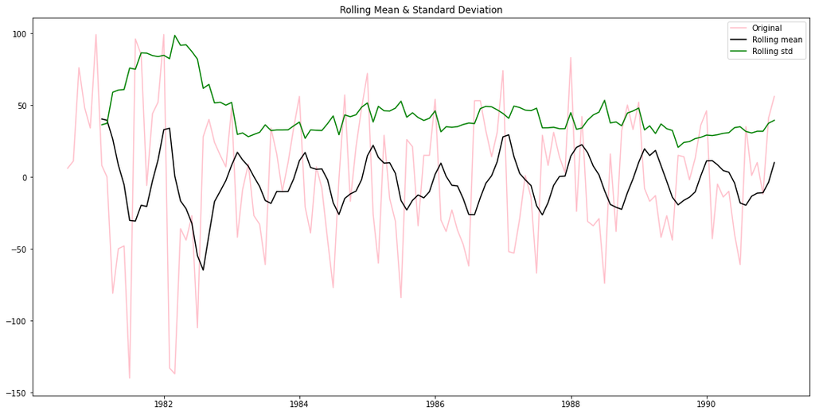

```python
#testing stationarity at diff 6

Stationarity_test(train['Rose'].diff(6).dropna())
```

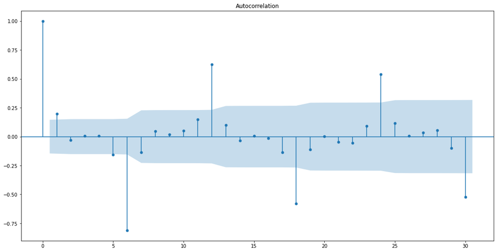

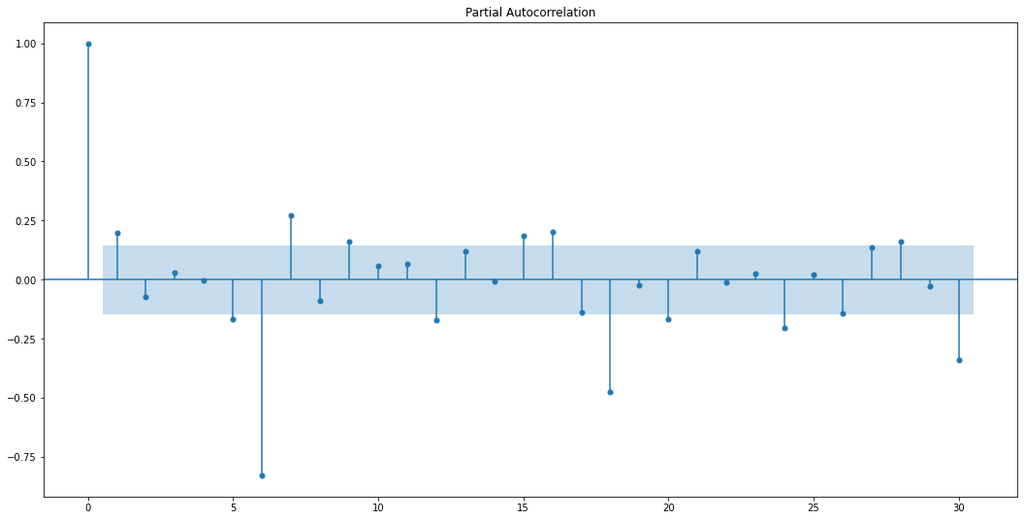

```python
#again plotting acf and pacf with diff 6

plot_acf((rose_data['Rose'].diff(6).dropna()),lags=30)
plot_pacf((rose_data['Rose'].diff(6).dropna()),lags=30);
```

Now, both the ACF and PACF plots have the cut off at 1. Alpha value at 0.05. we will check the ACF and PACF plots at a multiple of 6, because seasonal period is 6

```python
manual_SARIMA_model = sm.tsa.statespace.SARIMAX(train['Rose'].values,
                                order=(4, 1, 2),
                                seasonal_order=(1, 1, 1, 6),
                                enforce_stationarity=False,
                                enforce_invertibility=False)
results_manual_SARIMA_model = manual_SARIMA_model.fit(maxiter=1000)
```

```python
print(results_manual_SARIMA_model.summary())
```

```
                                      SARIMAX Results
===========================================================================================
Dep. Variable:                                   y   No. Observations:                  132
Model:             SARIMAX(4, 1, 2)x(1, 1, [1], 6)   Log Likelihood                -526.344
Date:                             Mon, 11 Oct 2021   AIC                           1070.688
Time:                                     23:17:00   BIC                           1095.393
Sample:                                          0   HQIC                          1080.716
                                             - 132
Covariance Type:                               opg
==============================================================================
                 coef    std err          z      P>|z|      [0.025      0.975]
------------------------------------------------------------------------------
ar.L1         -0.0722      0.270     -0.267      0.789      -0.601       0.457
ar.L2         -0.4955      0.141     -3.515      0.000      -0.772      -0.219
ar.L3         -0.0486      0.121     -0.401      0.688      -0.286       0.189
ar.L4         -0.3135      0.107     -2.926      0.003      -0.524      -0.104
ma.L1         87.5064   3459.696      0.025      0.980   -6693.373    6868.386
ma.L2        -56.4405   2197.671     -0.026      0.980   -4363.797    4250.916
ar.S.L6       -0.7330      0.066    -11.163      0.000      -0.862      -0.604
ma.S.L6       -1.4121      0.208     -6.779      0.000      -1.820      -1.004
sigma2         0.0341      2.673      0.013      0.990      -5.206       5.274
===================================================================================
Ljung-Box (L1) (Q):                   0.07   Jarque-Bera (JB):                23.99
Prob(Q):                              0.79   Prob(JB):                         0.00
Heteroskedasticity (H):               0.36   Skew:                             0.44
Prob(H) (two-sided):                  0.00   Kurtosis:                         5.06
===================================================================================

Warnings:
[1] Covariance matrix calculated using the outer product of gradients (complex-step).
```

```python
predicted_manual_SARIMA_model = results_manual_SARIMA_model.get_forecast(steps=len(test))
```

```python
#at aplha 0.05

predicted_manual_SARIMA_model.summary_frame(alpha=0.05).head()
```

| y | mean | mean_se | mean_ci_lower | mean_ci_upper |
| --- | --- | --- | --- | --- |
| 0 | 43.681048 | 22.984050 | -1.366863 | 88.728958 |
| 1 | 66.918041 | 23.988326 | 19.901786 | 113.934296 |
| 2 | 71.109578 | 24.245548 | 23.589177 | 118.629979 |
| 3 | 78.880894 | 24.588962 | 30.687415 | 127.074373 |
| 4 | 67.838140 | 24.693580 | 19.439612 | 116.236668 |

```python
#RMSE on test data

rmse_4 = mean_squared_error(test['Rose'],predicted_manual_SARIMA_model.predicted_mean,squared=False)

print(rmse_4)
```

```
19.004805582081588
```